# Ecopath mask builder

Alberto Rovellini

5/20/2021

# Purpose

Workflow to produce spatial masks for Ecopath GOA models from:

1. NMFS statistical areas
2. ETOPO depth raster

Two spatial masks are produced:

1. For the Western and Central GOA Ecopath model: NMFS areas 610, 620, 630; from 0 to 1000 m depth.
2. For the Eastern GOA Ecopath model: NMFS areas 640, 650; from 0 to 1000 m depth.

```r
select <- dplyr::select
```

## Read data

Read in statistical areas.

```r
nmfs <- st_read("data/shapefiles/gf95_nmfs/gf95_nmfs.shp")
nmfs <- nmfs %>% filter(NMFS_AREA %in% c(610,620,630,640,650)) %>% # subset to 610-650
  filter(GF95_NMFS1 %in% c(186,194,259,585,870)) %>% select(NMFS_AREA, geometry)
```

Visualise.

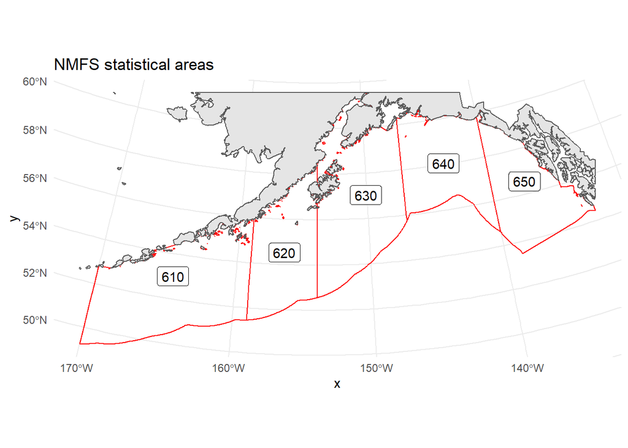

```r
coast <- map("worldHires", regions = "USA", plot = FALSE, fill = TRUE)
coast <- coast %>% st_as_sf() %>% st_transform(crs = st_crs(nmfs)) %>% st_crop(st_bbox(nmfs))
ggplot()+
  geom_sf(data = nmfs, fill = NA, color = "red")+
  geom_sf_label(data = nmfs, aes(label = NMFS_AREA))+
  geom_sf(data = coast)+
  theme_minimal()+
  labs(title = "NMFS statistical areas")
```

Read in depth raster.

```r
etopo <- raster("data/ETOPO1_Bed_c_gdal.grd/ETOPO1_Bed_c_gdal.grd")
```

Crop raster to extent of statistical areas (need to reproject that to 4326).

```r
nmfs_mask <- nmfs %>% st_transform(crs = 4326) %>% st_bbox() %>% extent() # get extent in 4326

etopo_goa <-  crop(etopo, nmfs_mask) # resize the raster to the study area
etopo_goa <- projectRaster(etopo_goa, crs = crs(nmfs)) # reproject
```

Visualise depth. Turn to sf for convenience.

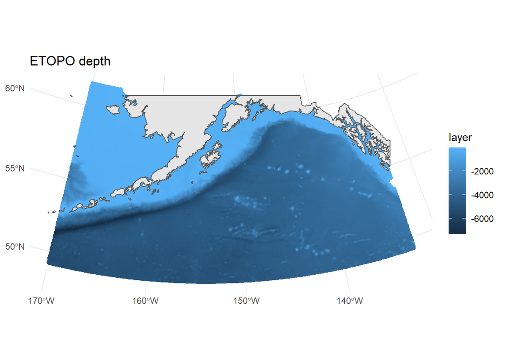

```r
etopo_sf <- etopo_goa %>%
  rasterToPoints() %>%
  data.frame() %>%
  st_as_sf(coords = c("x","y"), crs = crs(nmfs)) %>%
  filter(layer < 0)

etopo_sf <- etopo_sf[seq(1,nrow(etopo_sf),10),] # make this a little lighter for plotting

ggplot()+
  geom_sf(data = etopo_sf, aes(color = layer))+
  geom_sf(data = coast)+
  theme_minimal()+
  labs(title = "ETOPO depth")
```

## Process depth raster

Process the depth raster to create a single polygon to be used as a mask for the NMFS areas.

1. Clip the raster with the NMFS areas.
2. Subset the raster to the depth of interest (0-1000m).
3. Reclassify the raster so that all cells have the same value (1).
4. Polygonize the raster dissolving adjacent cells with equal values.
5. Disaggregate non-adjacent polygons.
6. Convert to sf object for ease of manipulation.
7. Filter out the seamounts to keep the shelf only.

```r
#1
etopo_nmfs <- mask(etopo_goa, nmfs)
#2
etopo_nmfs[etopo_nmfs[] < -1000] = NA
#3
etopo_nmfs <- etopo_nmfs %>% reclassify(rcl = c(-Inf, Inf, 1))
#4 this step takes some time
etopo_nmfs_pol <- etopo_nmfs %>% rasterToPolygons(dissolve = TRUE)
#5
etopo_nmfs_pols <- etopo_nmfs_pol %>% disaggregate()
#6
etopo_nmfs_sf <- etopo_nmfs_pols %>% st_as_sf() %>% mutate(index = 1:nrow(.))
#7
etopo_mask <- etopo_nmfs_sf[1,] # the main shelf polygon seems to be the first row
```

Visualise.

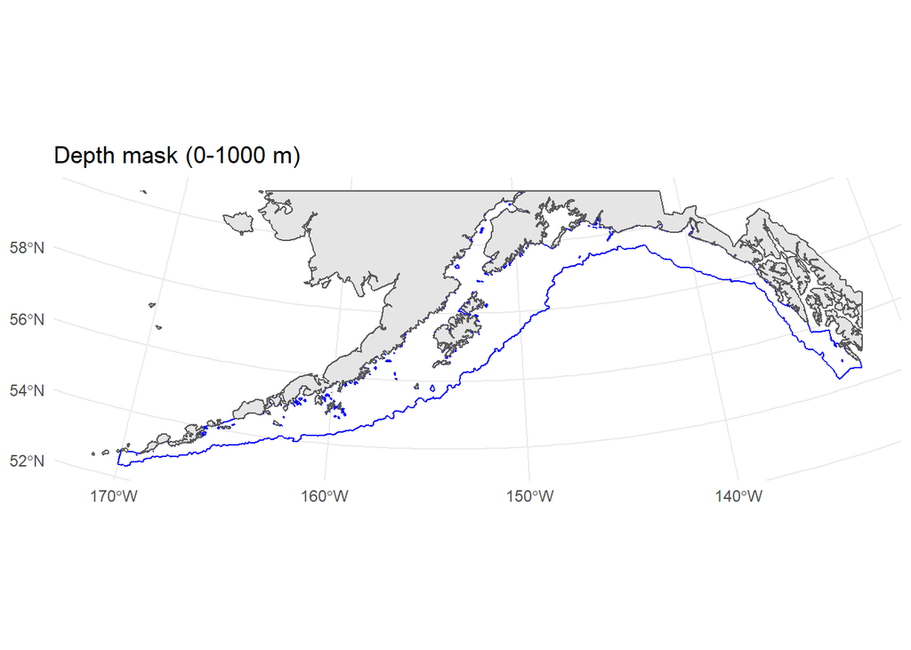

```r
ggplot()+
  geom_sf(data = etopo_mask, fill = NA, color = "blue")+
  geom_sf(data = coast)+
  theme_minimal()+
  labs(title = "Depth mask (0-1000 m)")
```

Visualise with the NMFS areas.

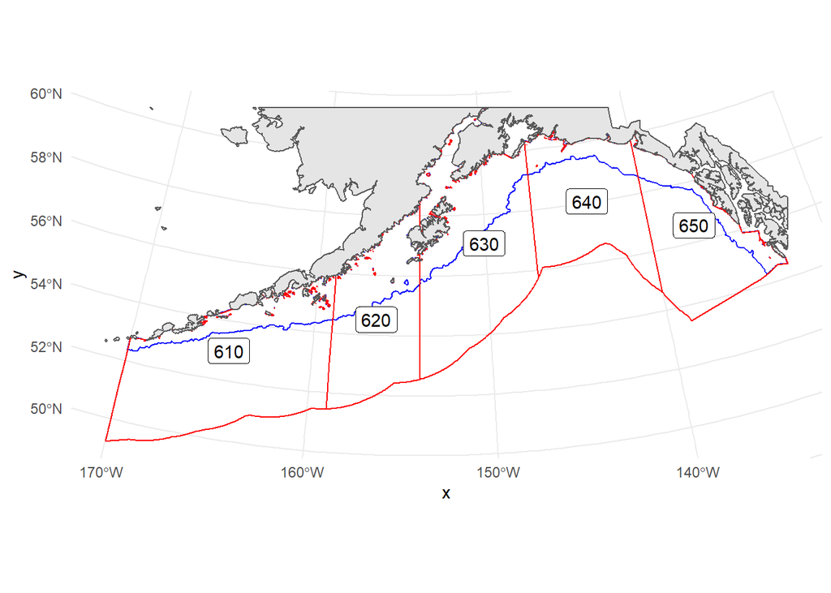

```r
ggplot()+
  geom_sf(data = etopo_mask, color = "blue", fill = NA)+
  geom_sf(data = nmfs, fill = NA, color = "red")+
  geom_sf_label(data = nmfs, aes(label = NMFS_AREA))+
  geom_sf(data = coast)+
  theme_minimal()
```

## Create spatial masks

Intersect these, and add “WGOA” and “EGOA” column for the respective areas.

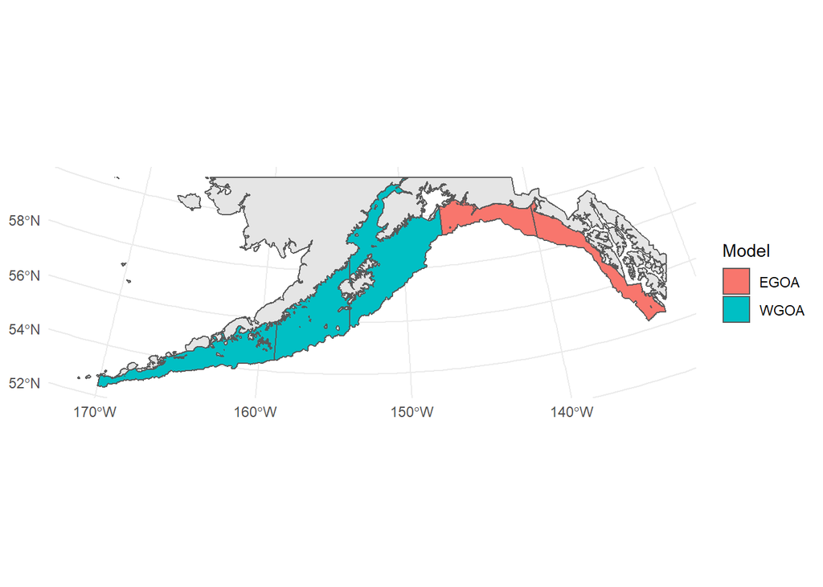

```r
ecopath <- etopo_mask %>%
  st_intersection(nmfs) %>%
  select(NMFS_AREA, geometry) %>%
  rowwise() %>%
  mutate(Model = ifelse(NMFS_AREA %in% c(640,650),"EGOA","WGOA"))

ggplot()+
  geom_sf(data = ecopath, aes(fill = Model))+
  geom_sf(data = coast)+
  theme_minimal()+
  labs("Masks for Ecopath GOA models")
```

Does the WGOA Ecopath model push all the way into Cook Inlet?

### Export as shapefiles

Export the two masks separately.

```r
WGOA <- ecopath %>% filter(NMFS_AREA %in% c(610,620,630))
EGOA <- ecopath %>% filter(NMFS_AREA %in% c(640,650))

st_write(WGOA, "WGOA.shp", append = FALSE)
st_write(EGOA, "EGOA.shp", append = FALSE)
```

**Note**: this could be refined. The current method produces a “jagged” contour of the mask along the 0 m and 1000 m isobaths, which is the result of converting the depth raster cells to a polygon mask. I think that for the purpose of approximating the area of the Ecopath models this is probably below rounding error, but I want to try and refine it at some point. It sould be a good placeholder for now.